# The Madness Behind March Madness

#### An Analysis by: Rahul Shah

Every March, college basektball fans rejoice as the annual March Madness tournament kicks off. Dubbed "The Big Dance," 64 Division 1 basketball teams play in a win or go home tournament over the span of three weeks, where only one team prevails and wins the championship. It is the season of upsets and Cinderella stories where each team competes to the fullest extent to make it the distance. There are over 350 D1 basketball teams, and only 64 make the tournament, so there has to be some sort of selection process. There are 32 D1 "conferences," or groupings of basketball teams (think of UMD being in the Big 10). There are conference tournaments and the winner of each conference is automatically selected for the tournament. From the remaining slots, the NCAA (National Collegiate Athletic Association) takes a look at every team's regular season stats and standings, and chooses the remaining 32 teams to participate. You can read more on how the tournament works [here](https://entertainment.howstuffworks.com/march-madness.htm).

Since the tournament was updated to 64 teams in 1985, there have been yearly competitions (bracket challenges) where people try to build the "perfect bracket" of all 63 games. Brackets are able to be published as soon as the official matchups are made, up until the first game starts, which is about a 4-day span. The odds of a perfect bracket are $\frac{1}{2^{63}}$ or $1:9.2$ quintillion. In the history of the competition, no one has ever made an official perfect bracket. For reference, in 2022 alone, there was about 70 million official brackets published, but not a single one was perfect. This draws in a vast audience, as they, including myself, want to be the first person ever to have a perfect bracket. From these facts, it makes sense to know a little about each team and the matchups in order to choose winners of each matchup accordingly.

We will perform data analysis on raw tournament matchups in a 35-year span from 1985-2019, then look at historically great basketball programs and see how they faired in the tournament, and then see how a team's performance in the regular season affect their progress in the tournament. Finally, we will hope to draw conclusions and make predictions on next tournament winners.

## Technologies to use

In order to perform our initial analysis we will use the [Python](https://docs.python.org/3/tutorial/index.html) language. [Pandas](https://pandas.pydata.org/docs/reference/index.html) is a Python-friendly framework that we use to store our data and it has in-built functions for analysis. A majority of our data analysis relies on graphs and plots. For this we will use [matplotlib](https://matplotlib.org/stable/tutorials/introductory/pyplot.html#sphx-glr-tutorials-introductory-pyplot-py) which is a graphical analysis tool that also has built-in functionality with Python. Tutorials can be found with the embedded hyperlinks. It is recommended to have some experience with Python before preceding, as things may get confusing otherwise.

## Raw Matchups

First we look at raw matchups. Our dataset only has years from 1985 to 2019, so we will analyze this 35-year span. This dataset can be downloaded from data.world [here](https://data.world/michaelaroy/ncaa-tournament-results).

```python
import pandas as pd
import numpy as np
import matplotlib.pyplot as plt

# Get data from .csv file
allgames = pd.read_csv('Big_Dance_CSV.csv')
display(allgames.head())
```

|  | Year | Round | Region Number | Region Name | Seed | Score | Team | Team.1 | Score.1 | Seed.1 |
| --- | --- | --- | --- | --- | --- | --- | --- | --- | --- | --- |
| 0 | 1985 | 1 | 1 | West | 1 | 83 | St Johns | Southern | 59 | 16 |
| 1 | 1985 | 1 | 1 | West | 2 | 81 | VCU | Marshall | 65 | 15 |
| 2 | 1985 | 1 | 1 | West | 3 | 65 | NC State | Nevada | 56 | 14 |
| 3 | 1985 | 1 | 1 | West | 4 | 85 | UNLV | San Diego St | 80 | 13 |
| 4 | 1985 | 1 | 1 | West | 5 | 58 | Washington | Kentucky | 65 | 12 |

We will add two new columns which see who the winner was for that specifc game, and what seed they were. This will help us later on determine the success of each seed and we will be able to perform better analysis with this.

```python
# Iterate through all games, compare scores, and update winner columns accordingly
for i, row in allgames.iterrows() :
    if row['Score'] > row['Score.1'] :
        allgames.at[i,'Winner'] = row['Team']
        allgames.at[i,'Winning Seed'] = row['Seed']
    else :
        allgames.at[i,'Winner'] = row['Team.1']
        allgames.at[i,'Winning Seed'] = row['Seed.1']
allgames = allgames.astype({'Winning Seed':'int'})
display(allgames)
```

|  | Year | Round | Region Number | Region Name | Seed | Score | Team | Team.1 | Score.1 | Seed.1 | Winner | Winning Seed |
| --- | --- | --- | --- | --- | --- | --- | --- | --- | --- | --- | --- | --- |
| 0 | 1985 | 1 | 1 | West | 1 | 83 | St Johns | Southern | 59 | 16 | St Johns | 1 |
| 1 | 1985 | 1 | 1 | West | 2 | 81 | VCU | Marshall | 65 | 15 | VCU | 2 |
| 2 | 1985 | 1 | 1 | West | 3 | 65 | NC State | Nevada | 56 | 14 | NC State | 3 |
| 3 | 1985 | 1 | 1 | West | 4 | 85 | UNLV | San Diego St | 80 | 13 | UNLV | 4 |
| 4 | 1985 | 1 | 1 | West | 5 | 58 | Washington | Kentucky | 65 | 12 | Kentucky | 12 |
| ... | ... | ... | ... | ... | ... | ... | ... | ... | ... | ... | ... | ... |
| 2200 | 2019 | 4 | 3 | East | 1 | 80 | Virginia | Purdue | 75 | 3 | Virginia | 1 |
| 2201 | 2019 | 4 | 4 | Midwest | 5 | 77 | Auburn | Kentucky | 71 | 2 | Auburn | 5 |
| 2202 | 2019 | 5 | 1 | Final Four | 2 | 51 | Michigan St | Texas Tech | 61 | 3 | Texas Tech | 3 |
| 2203 | 2019 | 5 | 2 | Final Four | 1 | 63 | Virginia | Auburn | 62 | 5 | Virginia | 1 |
| 2204 | 2019 | 6 | 1 | Championship | 3 | 77 | Texas Tech | Virginia | 85 | 1 | Virginia | 1 |

2205 rows × 12 columns

### Winning Seed Frequency

To get a grasp of how each seed fairs in the competition, we will look at the number of times each seed won each round of the tournament.

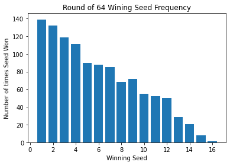

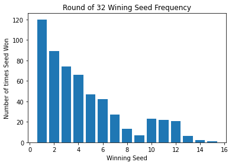

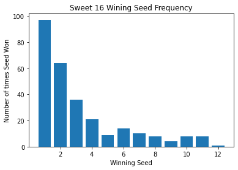

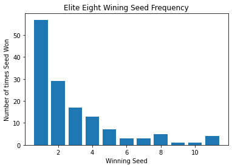

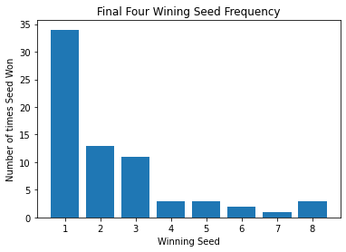

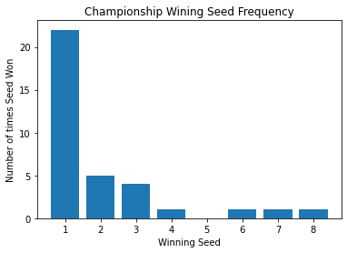

```python
# Helper function to get key by value from dictionary
def get_key(val, my_dict):
    for key, value in my_dict.items():
         if val == value:
             return key
    return "There is no such Key"
# Dictionary which tells us the number of wins a team has after progressing the correlated round.
rounds = {'Round of 64': 1, 'Round of 32': 2, 'Sweet 16': 3, 'Elite Eight': 4, 'Final Four': 5, 'Championship': 6}
# Iterate through each round in the tournament and grab the number of times each seed won that round. Plot on bar chart
for rd in rounds.values() :
    allgames_round = allgames.loc[allgames['Round'] == rd]
    winner_freq = allgames_round['Winning Seed'].value_counts()
    plt.figure(figsize=(6,4))
    plt.bar(winner_freq.index.to_list(), winner_freq.values)
    title = str(get_key(rd,rounds)) + ' Wining Seed Frequency'
    plt.title(title)
    plt.xlabel('Winning Seed')
    plt.ylabel('Number of times Seed Won')
```

From these charts, we can clearly see that the 1 seed outperforms all other seeds in the tournament. They have won the championship 22 times in the 35 years this data spans. There are also major upsets we can see. There is one instance where the 16 seed beat the 1 seed in the Round of 64. This was UMBC's legendary 20-point victory over UVA in 2018, who were tournament favorites. This goes down as one of the greatest, if not the greatest, single game upset in March Madness history. You can relive this instant classic [here](https://youtu.be/SuHVvSsNY2E). We can also see that in the Round of 64, the 9 seed has won more times than the 8 seed, by a very small margin. These seeds play against each other in this round and should be pretty evenly matched, so this series being close makes sense.

### Blue Bloods

There are historically great teams called 'Blue Bloods' that have deep roots in college basketball and have sustained success over the decades of the tournament. These teams being: Duke, Indiana, Kansas, Kentucky, North Carolina, and UCLA. There has been controversy of whether Indiana is still a Blue Blood, and if Villanova should take their place. We will take a look at each Blue Blood's sucess from 1985 to 2019 and see why there is this controversy.

To do this, we will plot the number of wins they have had each season. I chose to plot each Blue Blood on their own graph instead of having all of them on the same graph. I did this to reduce clutter and provide an easy visualization for each team's individual success.

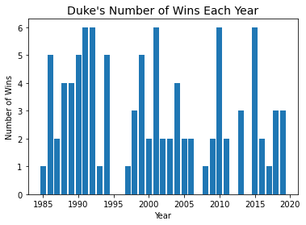

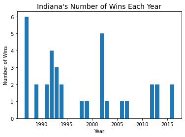

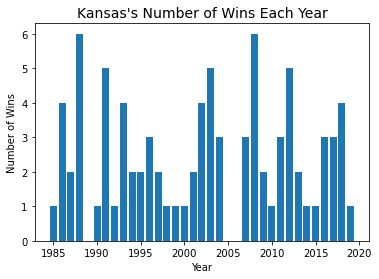

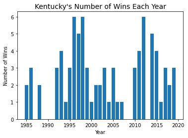

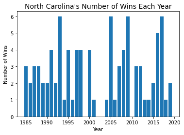

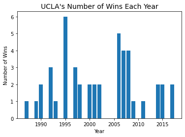

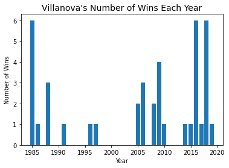

```python
# List of all Blue Bloods
bluebloods = ['Duke', 'Indiana', 'Kansas', 'Kentucky', 'North Carolina', 'UCLA', 'Villanova']
years = np.unique(allgames['Year'])

# Plot each Blue Blood number of wins in tournament
for team in bluebloods:
    # For each Blue Blood, grab matchups where they won
    df_numwins = pd.DataFrame()
    df_bb = allgames.loc[allgames['Winner'] == team]
    # Iterate through each year and find number of wins
    for year in years:
        numwins_year = df_bb.loc[df_bb['Year'] == year].iloc[-1:].reset_index()
        df_numwins = pd.concat([df_numwins, numwins_year], ignore_index=True)
    # Plot number of wins per year for each team
    plt.figure(figsize=(6,4))
    title = team + "'s" + " Number of Wins Each Year"
    plt.title(title, fontsize=14)
    plt.bar(df_numwins['Year'],df_numwins['Round'])
    plt.xlabel('Year')
    plt.ylabel('Number of Wins')
```

The number of wins a team has each year is equivalent to how far they made it in the tournament. For example, a team with 6 wins won the National Championship that year and a team with 0 wins either lost in the first round or failed to qualify for the tournament that year. As shown from these charts, Duke has had the most success in this 35 year span, winning 5 national championships. North Carolina comes in close with 4 national championships.

### Addressing Controversy

There has been much controversy on whether or not Indiana should retain their status as a Blue Blood. They have had the least success in this 35 year span, winning the title only one time. Most of their success comes from before 1985, when the tournament was not the full 64 teams. In this same aspect, UCLA only has one title in this span. However, they have 10 titles before 1985, and the most of any college basketball team, so their prominent history cannot be discarded, and thus, they are undoubtedly still a Blue Blood. There have been talks of whether Villanova should be recognized as a Blue Blood, as they are starting to show sucess in the tournament, winning two titles in three years.

The term 'Blue Blood' is unofficial and is only a status coined by the college basketball community, so having this title doesn't diminish any other teams' success. However, it is typically the pinnacle of achievement in college basketball and used to distinguish between the ultra elite.

## Analyzing Regular Season Statistics

We will now take a closer look to see how certain regular season statistics correlate to a team's performance in the tournament. The dataset we will look at only contains years 2013-2019, so we are unable to analyze regular season team data from 1985-2012. This dataset can be downloaded from kaggle [here](https://www.kaggle.com/datasets/andrewsundberg/college-basketball-dataset).

```python
# Load in dataset
stats_df = pd.read_csv('cbb.csv')
display(stats_df)
```

|  | TEAM | CONF | G | W | ADJOE | ADJDE | BARTHAG | EFG_O | EFG_D | TOR | ... | FTRD | 2P_O | 2P_D | 3P_O | 3P_D | ADJ_T | WAB | POSTSEASON | SEED | YEAR |
| --- | --- | --- | --- | --- | --- | --- | --- | --- | --- | --- | --- | --- | --- | --- | --- | --- | --- | --- | --- | --- | --- |
| 0 | North Carolina | ACC | 40 | 33 | 123.3 | 94.9 | 0.9531 | 52.6 | 48.1 | 15.4 | ... | 30.4 | 53.9 | 44.6 | 32.7 | 36.2 | 71.7 | 8.6 | 2ND | 1.0 | 2016 |
| 1 | Wisconsin | B10 | 40 | 36 | 129.1 | 93.6 | 0.9758 | 54.8 | 47.7 | 12.4 | ... | 22.4 | 54.8 | 44.7 | 36.5 | 37.5 | 59.3 | 11.3 | 2ND | 1.0 | 2015 |
| 2 | Michigan | B10 | 40 | 33 | 114.4 | 90.4 | 0.9375 | 53.9 | 47.7 | 14.0 | ... | 30.0 | 54.7 | 46.8 | 35.2 | 33.2 | 65.9 | 6.9 | 2ND | 3.0 | 2018 |
| 3 | Texas Tech | B12 | 38 | 31 | 115.2 | 85.2 | 0.9696 | 53.5 | 43.0 | 17.7 | ... | 36.6 | 52.8 | 41.9 | 36.5 | 29.7 | 67.5 | 7.0 | 2ND | 3.0 | 2019 |
| 4 | Gonzaga | WCC | 39 | 37 | 117.8 | 86.3 | 0.9728 | 56.6 | 41.1 | 16.2 | ... | 26.9 | 56.3 | 40.0 | 38.2 | 29.0 | 71.5 | 7.7 | 2ND | 1.0 | 2017 |
| ... | ... | ... | ... | ... | ... | ... | ... | ... | ... | ... | ... | ... | ... | ... | ... | ... | ... | ... | ... | ... | ... |
| 2450 | Michigan St. | B10 | 35 | 26 | 111.4 | 87.8 | 0.9392 | 50.6 | 44.5 | 20.8 | ... | 32.4 | 50.4 | 44.3 | 34.1 | 30.1 | 64.4 | 6.7 | S16 | 3.0 | 2013 |
| 2451 | Arizona | P12 | 35 | 27 | 114.4 | 92.2 | 0.9229 | 52.5 | 46.6 | 19.5 | ... | 32.9 | 50.6 | 43.4 | 37.1 | 35.8 | 66.8 | 4.6 | S16 | 6.0 | 2013 |
| 2452 | Oregon | P12 | 37 | 28 | 104.8 | 88.6 | 0.8728 | 49.3 | 46.4 | 21.4 | ... | 33.3 | 49.1 | 44.9 | 33.3 | 33.4 | 69.2 | 2.9 | S16 | 12.0 | 2013 |
| 2453 | La Salle | A10 | 34 | 24 | 112.0 | 96.2 | 0.8516 | 51.9 | 49.3 | 17.1 | ... | 28.5 | 49.3 | 50.6 | 37.7 | 30.2 | 66.0 | 0.3 | S16 | 13.0 | 2013 |
| 2454 | Florida Gulf Coast | ASun | 35 | 24 | 103.4 | 96.3 | 0.6952 | 51.6 | 46.9 | 21.0 | ... | 32.7 | 52.3 | 46.9 | 33.4 | 31.3 | 69.1 | -4.0 | S16 | 15.0 | 2013 |

2455 rows × 24 columns

There are some rows in this dataset with the POSTSEASON column as NULL. This where that specific team did not make the tournament that year. Because we are only focused in the teams that make the tournament, we drop these rows.

```python
# Drop any null values, or rows where the team did not make the tournament.
stats_df = stats_df.dropna()
stats_df.sort_values(by='YEAR', inplace=True)
```

The previous fact that the tournament consisted of 64 teams is a slight stretch. There are technically 68 teams in the tournament. There are four initial games called the 'First Four' which are essentially play-in games where the winner of each matchup advances to the main established tournament with 64 teams. With this fact in mind, we are only focused on the main 64-team bracket, so we drop any rows with the Round of 68 included.

```python
stats_df = stats_df[stats_df['POSTSEASON'] != 'R68']
stats_df = stats_df.reset_index(drop=True)
```

We add a row for Win Percentage for further future analysis.

```python
# Insert Win Percentage column at specified index with all Null values.
stats_df.insert(4, 'W_PCT', [np.nan] * len(stats_df))
# Iterate through each row and calculate win percentage.
for i, row in stats_df.iterrows():
    stats_df.at[i,'W_PCT'] = row['W'] / row['G'] * 100
display(stats_df)
```

|  | TEAM | CONF | G | W | W_PCT | ADJOE | ADJDE | BARTHAG | EFG_O | EFG_D | ... | FTRD | 2P_O | 2P_D | 3P_O | 3P_D | ADJ_T | WAB | POSTSEASON | SEED | YEAR |
| --- | --- | --- | --- | --- | --- | --- | --- | --- | --- | --- | --- | --- | --- | --- | --- | --- | --- | --- | --- | --- | --- |
| 0 | Florida Gulf Coast | ASun | 35 | 24 | 68.571429 | 103.4 | 96.3 | 0.6952 | 51.6 | 46.9 | ... | 32.7 | 52.3 | 46.9 | 33.4 | 31.3 | 69.1 | -4.0 | S16 | 15.0 | 2013 |
| 1 | South Dakota St. | Sum | 32 | 22 | 68.750000 | 109.7 | 103.7 | 0.6573 | 53.3 | 51.2 | ... | 24.4 | 50.4 | 49.8 | 38.9 | 35.8 | 64.0 | -3.2 | R64 | 13.0 | 2013 |
| 2 | Montana | BSky | 30 | 23 | 76.666667 | 101.6 | 101.8 | 0.4929 | 52.9 | 48.6 | ... | 35.9 | 52.0 | 48.0 | 36.4 | 33.3 | 63.9 | -1.4 | R64 | 13.0 | 2013 |
| 3 | New Mexico St. | WAC | 34 | 23 | 67.647059 | 102.5 | 95.3 | 0.6992 | 49.3 | 45.4 | ... | 30.7 | 49.8 | 43.2 | 31.8 | 33.9 | 65.1 | -3.1 | R64 | 13.0 | 2013 |
| 4 | Northwestern St. | Slnd | 28 | 19 | 67.857143 | 104.8 | 102.1 | 0.5730 | 49.0 | 47.8 | ... | 40.5 | 50.0 | 46.8 | 31.0 | 33.9 | 73.0 | -3.2 | R64 | 14.0 | 2013 |
| ... | ... | ... | ... | ... | ... | ... | ... | ... | ... | ... | ... | ... | ... | ... | ... | ... | ... | ... | ... | ... | ... |
| 443 | Yale | Ivy | 29 | 22 | 75.862069 | 110.5 | 102.5 | 0.7034 | 55.6 | 47.3 | ... | 31.1 | 56.0 | 47.8 | 36.5 | 31.0 | 72.2 | -0.9 | R64 | 14.0 | 2019 |
| 444 | Iona | MAAC | 33 | 17 | 51.515152 | 105.2 | 108.8 | 0.4044 | 53.0 | 52.3 | ... | 28.5 | 53.2 | 50.3 | 35.1 | 36.6 | 71.9 | -10.4 | R64 | 16.0 | 2019 |
| 445 | Iowa | B10 | 35 | 23 | 65.714286 | 116.1 | 100.6 | 0.8385 | 52.7 | 51.5 | ... | 28.8 | 51.4 | 53.5 | 36.4 | 32.4 | 70.9 | 3.2 | R32 | 10.0 | 2019 |
| 446 | Minnesota | B10 | 36 | 22 | 61.111111 | 110.4 | 96.3 | 0.8284 | 48.2 | 49.5 | ... | 28.2 | 48.5 | 48.7 | 31.7 | 34.0 | 68.8 | 2.7 | R32 | 10.0 | 2019 |
| 447 | New Mexico St. | WAC | 33 | 30 | 90.909091 | 111.8 | 98.2 | 0.8155 | 54.1 | 48.9 | ... | 32.5 | 56.7 | 48.0 | 34.0 | 33.5 | 67.1 | 1.4 | R64 | 12.0 | 2019 |

448 rows × 25 columns

Now we can take a look at a team's regular season win percentage and compare it to how well they faired in the tournament. For the plot, I used [seaborn](https://seaborn.pydata.org/introduction.html) which is another graphical analysis tool in Python. This uses matplotlib inheritly, but it adds an extra layer of customizations for our plots. We could have used matplotlib by itself however, but it would have been more complicated for our purposes.

The dataset we are currently using does things a little differently than before. Their rounds are equal to the number of wins a team has after losing that round. Or in the case of the championship round, the chapmions have 6 wins and the runner ups have 5. It's a little different than what was analyzed before, but we are still able to perform analysis.

```python
import seaborn as sns
years = np.unique(stats_df['YEAR'])
# Dict with rounds and number of wins as described above
rounds = {'R64': 0, 'R32': 1, 'S16': 2, 'E8': 3, 'F4': 4, '2ND': 5, 'Champions': 6}
for i, row in stats_df.iterrows():
    stats_df.at[i,'POST_ROUND'] = rounds.get(row['POSTSEASON'])
display(stats_df.head())
```

|  | TEAM | CONF | G | W | W_PCT | ADJOE | ADJDE | BARTHAG | EFG_O | EFG_D | ... | 2P_O | 2P_D | 3P_O | 3P_D | ADJ_T | WAB | POSTSEASON | SEED | YEAR | POST_ROUND |
| --- | --- | --- | --- | --- | --- | --- | --- | --- | --- | --- | --- | --- | --- | --- | --- | --- | --- | --- | --- | --- | --- |
| 0 | Florida Gulf Coast | ASun | 35 | 24 | 68.571429 | 103.4 | 96.3 | 0.6952 | 51.6 | 46.9 | ... | 52.3 | 46.9 | 33.4 | 31.3 | 69.1 | -4.0 | S16 | 15.0 | 2013 | 2.0 |
| 1 | South Dakota St. | Sum | 32 | 22 | 68.750000 | 109.7 | 103.7 | 0.6573 | 53.3 | 51.2 | ... | 50.4 | 49.8 | 38.9 | 35.8 | 64.0 | -3.2 | R64 | 13.0 | 2013 | 0.0 |
| 2 | Montana | BSky | 30 | 23 | 76.666667 | 101.6 | 101.8 | 0.4929 | 52.9 | 48.6 | ... | 52.0 | 48.0 | 36.4 | 33.3 | 63.9 | -1.4 | R64 | 13.0 | 2013 | 0.0 |
| 3 | New Mexico St. | WAC | 34 | 23 | 67.647059 | 102.5 | 95.3 | 0.6992 | 49.3 | 45.4 | ... | 49.8 | 43.2 | 31.8 | 33.9 | 65.1 | -3.1 | R64 | 13.0 | 2013 | 0.0 |
| 4 | Northwestern St. | Slnd | 28 | 19 | 67.857143 | 104.8 | 102.1 | 0.5730 | 49.0 | 47.8 | ... | 50.0 | 46.8 | 31.0 | 33.9 | 73.0 | -3.2 | R64 | 14.0 | 2013 | 0.0 |

5 rows × 26 columns

Now that we have our dictionaries and data storage, we can create our scatter plot. We could have instead used a line graph ploting the trend of win percentage each year, but I chose a scatter plot to avoid the clutter that comes with a line graph. Seaborn has an easy way to create a scatterplot without iterating through each row, so I did this. I used colors to distinguish each year from each other.

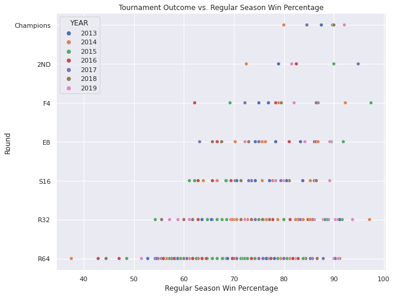

```python
# Sort DataFrame by round so scatter plot order makes sense
stats_df = stats_df.sort_values(by=['POST_ROUND'], ascending=False)
# Figure dimensions
sns.set(rc={"figure.figsize":(10, 8)})
# Plot and set labels
ax = sns.scatterplot(data=stats_df, x='W_PCT', y='POSTSEASON', hue='YEAR', palette='deep')
ax.set(xlabel='Regular Season Win Percentage', ylabel='Round', title='Tournament Outcome vs. Regular Season Win Percentage')
plt.show()
```

Just by looking at this chart, we can see that the spread of regular season win percentage decreases as the round increases.  
We will justify our chart by calculating the average regular season win percentage for each round in the tournament.

```python
print("Average Regular Season Win Percentage for teams ending as: ")
# Iterate through each round and find avg win percentage for that round
for rd in rounds.keys():
    rd_df = stats_df.loc[stats_df['POSTSEASON'] == rd]
    mean_wpct = round(rd_df['W_PCT'].mean(), 2)
    print(str(rd) + " is " + str(mean_wpct) + "%")
```

```
Average Regular Season Win Percentage for teams ending as:
R64 is 68.87%
R32 is 74.13%
S16 is 74.61%
E8 is 78.45%
F4 is 79.6%
2ND is 83.27%
Champions is 87.35%
```

From these stats, the average regular season win percentage consistently increases as the rounds increase. So typically, teams with higher win percentages in the regular season advance further in the tournament, which is to be expected.

Win percentage isn't the only stat that matters in the regular season, so next, we will take a look at other regular season stats and see how they affect outcomes in the tournament.

We take a look at teams offensive and defensive efficiencies. Adjusted Offensive Efficiency (ADJOE) is defined as a team's points scored per 100 possessions on the average D1 defense. Adjusted Defensive Efficiency (ADJDE) is defined as a team's points allowed per 100 possessions on the average D1 offense.

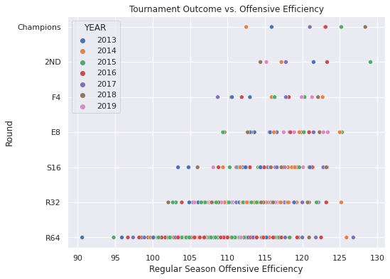

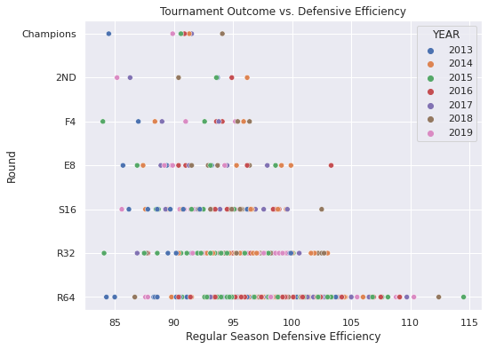

```
Average Offensive Efficiency for teams ending as:
R64 is 108.72
R32 is 112.83
S16 is 115.51
E8 is 117.74
F4 is 116.37
2ND is 119.79
Champions is 121.3

Average Defensive Efficiency for teams ending as:
R64 is 98.54
R32 is 95.06
S16 is 93.75
E8 is 92.81
F4 is 91.96
2ND is 91.47
Champions is 90.4
```

```python
# Plot Offensive Efficiency
sns.set(rc={"figure.figsize":(8, 6)})
ax1 = sns.scatterplot(data=stats_df, x='ADJOE', y='POSTSEASON', hue='YEAR', palette='deep')
ax1.set(xlabel='Regular Season Offensive Efficiency', ylabel='Round', title='Tournament Outcome vs. Offensive Efficiency')
plt.show()
# Plot Defensive Efficiency
sns.set(rc={"figure.figsize":(8, 6)})
ax2 = sns.scatterplot(data=stats_df, x='ADJDE', y='POSTSEASON', hue='YEAR', palette='deep')
ax2.set(xlabel='Regular Season Defensive Efficiency', ylabel='Round', title='Tournament Outcome vs. Defensive Efficiency')
plt.show()

# Print out efficiency averages per round
print('Average Offensive Efficiency for teams ending as: ')
for rd in rounds.keys():
    rd_df = stats_df.loc[stats_df['POSTSEASON'] == rd]
    mean_wpct = round(rd_df['ADJOE'].mean(), 2)
    print(str(rd) + " is " + str(mean_wpct))
print('\nAverage Defensive Efficiency for teams ending as: ')
for rd in rounds.keys():
    rd_df = stats_df.loc[stats_df['POSTSEASON'] == rd]
    mean_wpct = round(rd_df['ADJDE'].mean(), 2)
    print(str(rd) + " is " + str(mean_wpct))
```

From the definitions listed earlier, it is better for teams to have a higher offensive efficiency (more points scored) and a lower defensive efficiency (less points allowed). From the charts and the averages computed, the teams that ended up winning the tournament on average have the highest offensive and lowest defensive efficiencies.

## Predicting Outcomes

Now, let's run some [linear regression](https://en.wikipedia.org/wiki/Linear_regression) to see if there is a sufficient correlation between win percentage, offensive efficiency, and defensive efficiency, vs a team's outcome in the tournament. To accomplish this, I used seaborn for the regression plots and statsmodels for the coefficient values.

There are 64 teams in the tournament, and only half of these teams make it out of the first round. So, to localize our data, we will only keep teams that reach the final four and beyond; so teams with 4, 5, or 6 wins in the tournament. This will give us a better understanding on how stats correlate to success.

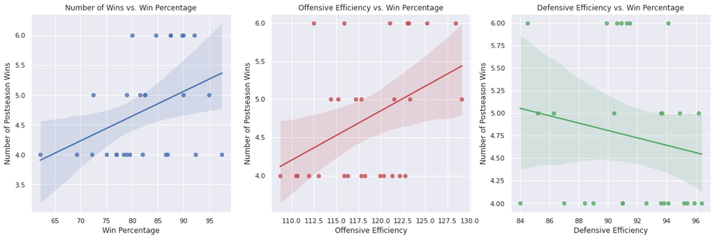

```python
import statsmodels.formula.api as statsmodels

stats_finalfour = stats_df.loc[stats_df['POSTSEASON'].isin(['F4', '2ND', 'Champions'])]
# Create subplots
fig, axes = plt.subplots(1,3, figsize=(20,6))
# Plot stats and regression line
sns.regplot(ax=axes[0], y='POST_ROUND', x='W_PCT', data = stats_finalfour, color='b')
sns.regplot(ax=axes[1], y='POST_ROUND', x='ADJOE', data = stats_finalfour, color='r')
sns.regplot(ax=axes[2], y='POST_ROUND', x='ADJDE', data = stats_finalfour, color='g')
# Set titles, xlabels, and ylabels
axes[0].set_title('Number of Wins vs. Win Percentage')
axes[1].set_title('Offensive Efficiency vs. Win Percentage')
axes[2].set_title('Defensive Efficiency vs. Win Percentage')
axes[0].set_xlabel('Win Percentage')
axes[1].set_xlabel('Offensive Efficiency')
axes[2].set_xlabel('Defensive Efficiency')
for i in range(0,3):
    axes[i].set_ylabel('Number of Postseason Wins')
```

From these three plots, it seems that win percentage and offensive efficiency contribute the most to a team's success in the postseason. Let's back this up with some coefficients.

```python
# Models for number of wins vs. each statistic
wpct_model = statsmodels.ols(formula = 'POST_ROUND ~ W_PCT', data = stats_finalfour).fit()
adjoe_model = statsmodels.ols(formula = 'POST_ROUND ~ ADJOE', data = stats_finalfour).fit()
adjde_model = statsmodels.ols(formula = 'POST_ROUND ~ ADJDE', data = stats_finalfour).fit()
print('Win Percentage R^2: {}'.format(wpct_model.rsquared))
print('Offensive Efficiency R^2: {}'.format(adjoe_model.rsquared))
print('Defensive Efficiency R^2: {}'.format(adjde_model.rsquared))
```

```
Win Percentage R^2: 0.15992385596478398
Offensive Efficiency R^2: 0.16486594610489758
Defensive Efficiency R^2: 0.030826302249686188
```

The R^2 value for win percentage and Offensive Efficiency is much higher than that for Defensive Efficiency, but still very low. This may lead teams to focus more on the offensive side of basketball to win games rather than extra emphasis on defense. This is not say that defensive is not important at all; it just may not be as important as offensive in the grand scheme of things.

## Conclusion

From looking at various statistics across March Madness, we were able to analyze which teams win their tournament games and how they do it. Once matchups are published, bracket enthusiasts can see what seeds have the more favorable matchups and pick teams that way. They can also look at historically great teams and see if they can continue their greatness, or fail to prevail that year. Finally, looking at regular season statistics is a great way to see how good a team really is, and be able to compare teams that way to choose their winners. However, there still is various uncertainty, especially seen in how low all the R^2 values were, proving there is Madness in March.